# Offline Model Development

```python
import os
import sklearn
import pandas as pd
import numpy as np
import pyarrow as pa
import pyarrow.feather as feather
from minio import Minio
from dotenv import load_dotenv
import warnings
warnings.filterwarnings('ignore')
```

## Grabbing feather file from Minio

```python
# This notebook assumes .env file with these variables defined for fetching batch
load_dotenv()
MINIO_URL = os.getenv('MINIO_URL')
MINIO_ACCESS_KEY = os.getenv('MINIO_ACCESS_KEY')
MINIO_SECRET_KEY = os.getenv('MINIO_SECRET_KEY')
MINIO_BUCKET = os.getenv('MINIO_BUCKET')
MINIO_DIRECTORY = os.getenv('MINIO_DIRECTORY')
MINIO_OBJECT_NAME = os.getenv('MINIO_OBJECT_NAME')
```

```python
minio_client = Minio(MINIO_URL, access_key=MINIO_ACCESS_KEY, secret_key=MINIO_SECRET_KEY, secure=False)
```

```python
feather_obj = minio_client.get_object(MINIO_BUCKET, MINIO_DIRECTORY+"/"+MINIO_OBJECT_NAME).read()
```

```python
reader = pa.BufferReader(feather_obj)
df = feather.read_feather(reader)
df['date'] = pd.to_datetime(df['date'])
```

```python
df.head()
```

|  | id | date | price | bedrooms | bathrooms | sqft_living | sqft_lot | floors | waterfront | view | ... | sqft_basement | yr_built | yr_renovated | zipcode | lat | long | sqft_living15 | sqft_lot15 | zip_population | zip_schools |
| --- | --- | --- | --- | --- | --- | --- | --- | --- | --- | --- | --- | --- | --- | --- | --- | --- | --- | --- | --- | --- | --- |
| 0 | 4139440610 | 2014-05-12 | 746000.0 | 3 | 2.50 | 2620 | 8950 | 2.0 | 0 | 0 | ... | 0 | 1992 | 0 | 98006 | 47.5523 | -122.119 | 2850 | 8809 | 109092 | 1 |
| 1 | 5075400150 | 2014-05-23 | 585000.0 | 3 | 2.00 | 1670 | 4572 | 1.5 | 0 | 0 | ... | 0 | 1931 | 0 | 98117 | 47.6854 | -122.373 | 1480 | 4890 | 94095 | 2 |
| 2 | 2115510300 | 2014-10-16 | 246000.0 | 3 | 2.25 | 1440 | 10500 | 1.0 | 0 | 0 | ... | 310 | 1983 | 0 | 98023 | 47.3180 | -122.391 | 1510 | 8125 | 142530 | 2 |
| 3 | 4206901215 | 2014-06-12 | 920000.0 | 4 | 3.25 | 2420 | 4000 | 1.5 | 0 | 0 | ... | 550 | 1911 | 0 | 98105 | 47.6567 | -122.325 | 1810 | 4000 | 131772 | 1 |
| 4 | 3754501240 | 2015-02-06 | 1550000.0 | 3 | 4.00 | 5120 | 4600 | 3.0 | 0 | 2 | ... | 630 | 2008 | 0 | 98034 | 47.7052 | -122.223 | 2510 | 5918 | 121221 | 3 |

5 rows × 23 columns

## Feature Exploration

```python
from mpl_toolkits.mplot3d import Axes3D
from matplotlib import colors
import matplotlib.pyplot as plt
import seaborn as sns
```

```python
# Sort dataframe by date for the Time Series CV later on
data = df.sort_values(by='date').reset_index(drop=True)

# Extract out year and month into separate features
data['year'] = data['date'].dt.year
data['month'] = data['date'].dt.month

# Bucket months into seasons
season_buckets = {12: 'winter', 1: 'winter', 2: 'winter',
                  3: 'spring', 4: 'spring', 5: 'spring',
                  6: 'summer', 7: 'summer', 8: 'summer',
                  9: 'fall', 10: 'fall', 11: 'fall'}
data['season'] = data['month'].replace(season_buckets)

# Distance from county "center"
center_lat, center_long = 47.6373, -122.224
data['distance'] = ((center_long - data['long'])**2 + (center_lat - data['lat'])**2) **.5

categorical_features = ['bedrooms','bathrooms','floors','waterfront','view','condition','grade','yr_built','yr_renovated','zipcode','year','month','season']
data[categorical_features] = data[categorical_features].astype('category')
```

```python
data.info()
```

```
<class 'pandas.core.frame.DataFrame'>
RangeIndex: 10798 entries, 0 to 10797
Data columns (total 27 columns):
 #   Column          Non-Null Count  Dtype
---  ------          --------------  -----
 0   id              10798 non-null  int64
 1   date            10798 non-null  datetime64[ns]
 2   price           10798 non-null  float64
 3   bedrooms        10798 non-null  category
 4   bathrooms       10798 non-null  category
 5   sqft_living     10798 non-null  int64
 6   sqft_lot        10798 non-null  int64
 7   floors          10798 non-null  category
 8   waterfront      10798 non-null  category
 9   view            10798 non-null  category
```

[output cut: 19 more lines]

### Price Location Visualization

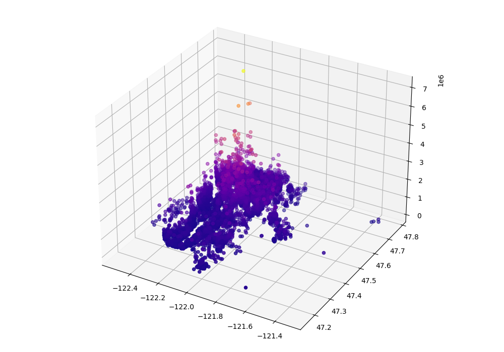

```python
%matplotlib widget
fig = plt.figure(figsize=(10,7))
ax = Axes3D(fig)
ax.scatter(data['long'], data['lat'], data['price'], c=data['price'], cmap='plasma')
plt.show()
```

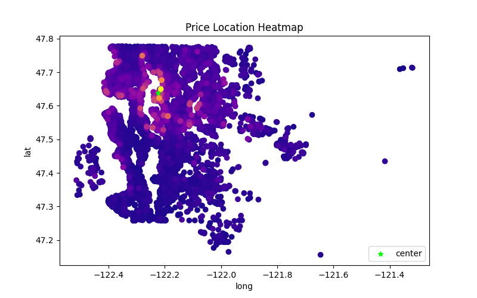

```python
# Temporarily sort by price so higher priced points show up on top
data2 = data.sort_values(by='price', ascending=True).reset_index(drop=True)
plt.figure(figsize=(8,5))
plt.scatter(data2['long'], data2['lat'], c=data2['price'], cmap='plasma')
plt.scatter(center_long, center_lat, c='lime', marker='*', label='center')
plt.xlabel('long')
plt.ylabel('lat')
plt.title('Price Location Heatmap')
plt.legend(loc='lower right')
plt.show()
```

### Numeric Features

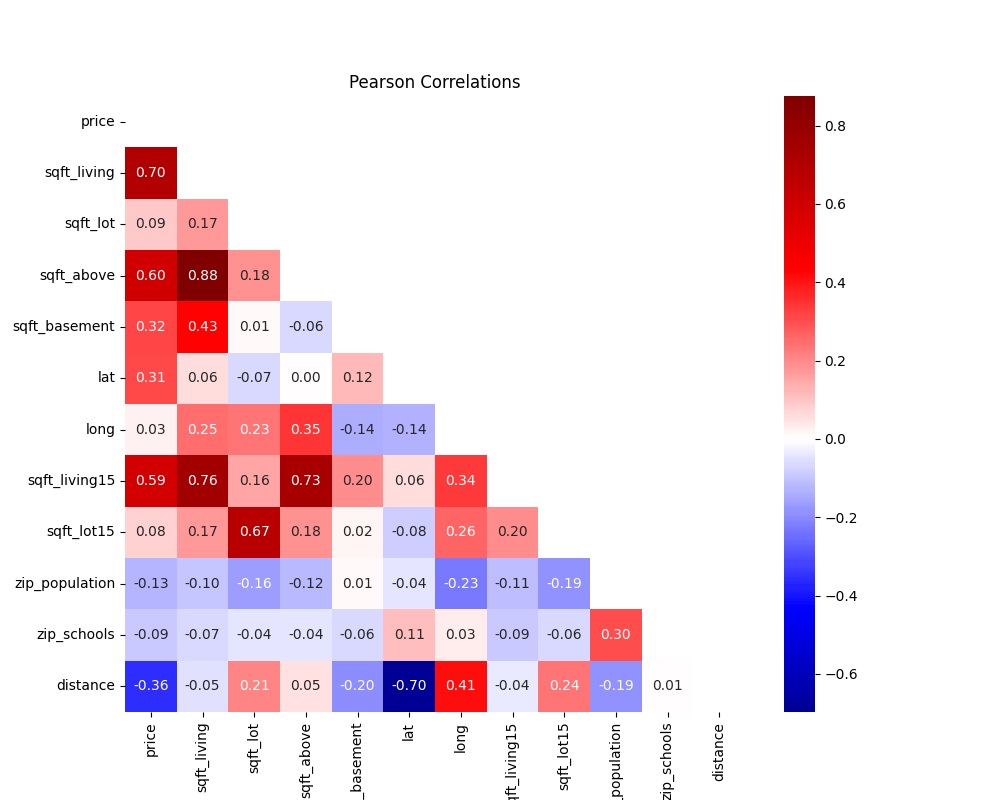

```python
corr_matrix = data.drop(categorical_features+['id'], axis=1).corr()
plt.figure(figsize=(10,8))
mask = np.triu(np.ones_like(corr_matrix))
sns.heatmap(corr_matrix, annot=True, cmap='seismic', fmt=".2f", center=0, mask=mask)
plt.title('Pearson Correlations')
plt.show()
```

### Categorical Features

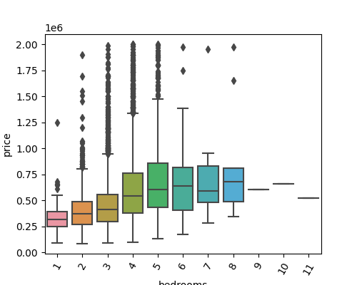

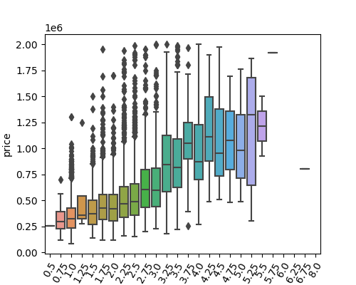

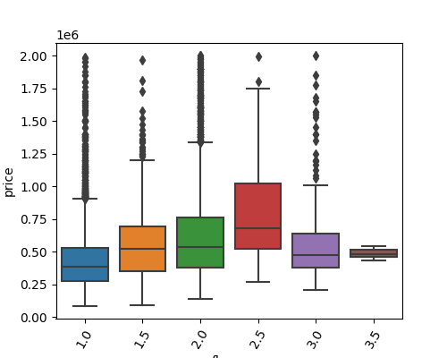

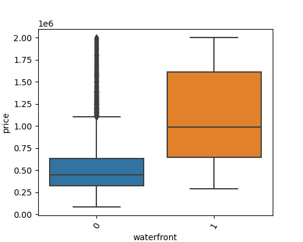

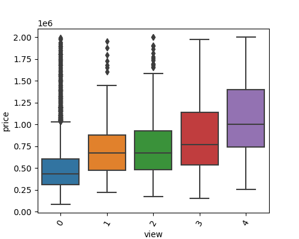

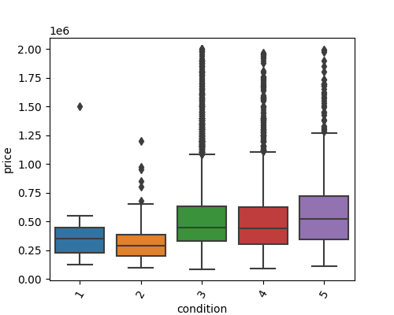

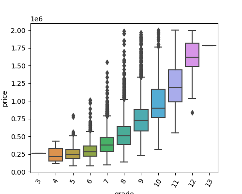

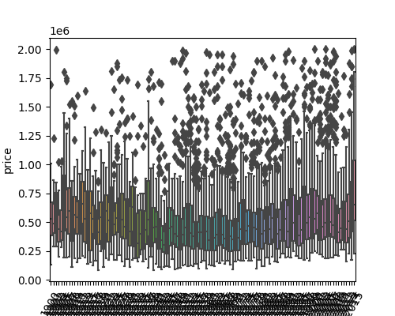

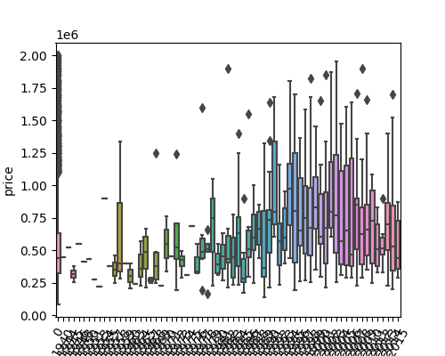

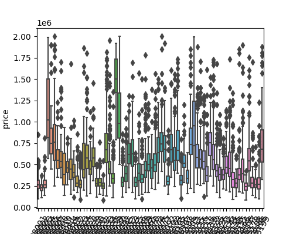

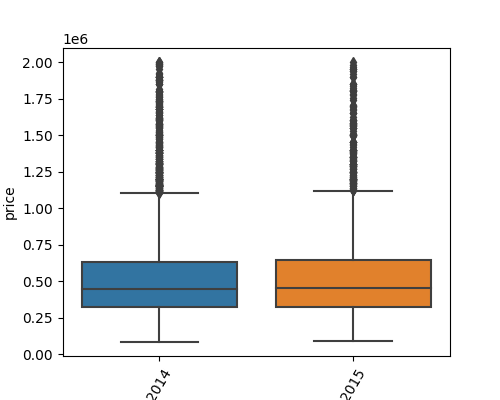

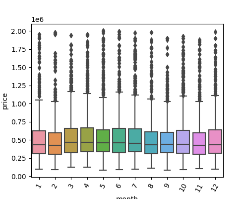

[1 more figures not shown]

```python
for var in categorical_features:
    plt.figure(figsize=(5, 4))
    # The ~1% of records above $2 million are cropped out here so the plots are cleaner
    sns.boxplot(data=data[data['price'] <= 2_000_000], x=var, y='price')
    plt.xticks(rotation=60)
    plt.show()
```

## Model Selection

With Time Series Cross-validation & Grid Search. Models tested:

- Elastic-Net
- Random Forest Regressor
- Gradient Boosting Regressor

Originally included Support Vector Regression, but it kept breaking with grid search. Setting Elastic-Net parameters allows us to use just L1 or L2 penality term, so we are essentially also testing Rigde and Lasso Regression in its grid search.

```python
from sklearn.model_selection import TimeSeriesSplit
from sklearn.model_selection import GridSearchCV
from sklearn.linear_model import ElasticNet
from sklearn.ensemble import RandomForestRegressor
from sklearn.ensemble import GradientBoostingRegressor
from sklearn.compose import ColumnTransformer
from sklearn.pipeline import Pipeline
from sklearn.pipeline import make_pipeline
from sklearn.preprocessing import StandardScaler, OneHotEncoder
```

```python
params = {
        'Elastic-Net': {'model__alpha': [0, 0.1, 0.25, 0.5, 0.75, 1.0], 'model__l1_ratio': [0, 0.5, 1]},
        'Random Forest': {'model__max_depth': [2**x for x in range(1,6)], 'model__min_samples_leaf': [1, 3, 5, 10, 25], 'model__n_estimators': [100, 500, 1000, 1500]},
        'Gradient Boosting Regressor': {'model__learning_rate': [0.001, 0.01, 0.1], 'model__n_estimators': [2**x for x in range(7,11)], 'model__max_depth':[3, None]}
    }

scoring = {'RMSE': 'neg_root_mean_squared_error', 'MAPE': 'neg_mean_absolute_percentage_error'}
```

```python
n_splits = 5
tss = TimeSeriesSplit(n_splits=n_splits)
```

```python
def build_preprocessor(numeric_features, categorical_features):
    return ColumnTransformer(
            transformers=[('numeric', StandardScaler(), numeric_features),
                          ('categorical', OneHotEncoder(handle_unknown='ignore'), categorical_features)
    ])
```

```python
splits = range(n_splits)
train_RMSE_names = [f"split{i}_train_RMSE" for i in splits]
test_RMSE_names = [f"split{i}_test_RMSE" for i in splits]
train_MAPE_names = [f"split{i}_train_MAPE" for i in splits]
test_MAPE_names = [f"split{i}_test_MAPE" for i in splits]

def graph_results(exp_name, results):
    fig, axes = plt.subplots(3, 2, figsize=(10,10))
    fig.subplots_adjust(wspace=0.5, hspace=0.5)
    fig.suptitle(exp_name)

    for ax, pair in zip(axes, results):
        result = pair[1]
        ax[0].plot(splits, -result[train_RMSE_names], label='train')
        ax[0].plot(splits, -result[test_RMSE_names], label='test')
        ax[0].set_title(f"{pair[0]} Best RMSE: {-result['mean_test_RMSE']:.3f}")
        ax[0].set_xlabel('split')
        ax[0].set_ylabel('RMSE')
        ax[0].legend()

        ax[1].plot(splits, -result[train_MAPE_names], label='train')
        ax[1].plot(splits, -result[test_MAPE_names], label='test')
        ax[1].set_title(f"{pair[0]} Best MAPE: {-result['mean_test_MAPE']:.3f}")
        ax[1].set_xlabel('split')
        ax[1].set_ylabel('MAPE')
        ax[1].legend()

    plt.show()
```

### Experiment 1 - Base Features

Start with features found in the original DataFrame, keeping only `year` and `month` for the date

```python
categorical_features = ['bedrooms','bathrooms','floors','waterfront','view','condition','grade',\
                        'yr_built','yr_renovated','zipcode','year','month']

numeric_features = ['sqft_living','sqft_lot','sqft_above','sqft_basement','lat','long',\
                    'sqft_living15','sqft_lot15','zip_population','zip_schools']

X = data[numeric_features + categorical_features]
y = data['price']

preprocessor = build_preprocessor(numeric_features, categorical_features)
```

```python
%%time
grid_EN = GridSearchCV(Pipeline(steps=[('preprocessor', preprocessor), ('model', ElasticNet())]),
             param_grid=params['Elastic-Net'],
             cv=tss,
             scoring=scoring,
             refit='RMSE',
             return_train_score=True,
             n_jobs=4)

grid_EN.fit(X, y)
```

```
CPU times: total: 5.91 s
Wall time: 52.2 s
```

```
GridSearchCV(cv=TimeSeriesSplit(gap=0, max_train_size=None, n_splits=5, test_size=None),
             estimator=Pipeline(steps=[('preprocessor',
                                        ColumnTransformer(transformers=[('numeric',
                                                                         StandardScaler(),
                                                                         ['sqft_living',
                                                                          'sqft_lot',
                                                                          'sqft_above',
                                                                          'sqft_basement',
                                                                          'lat',
                                                                          'long',
                                                                          'sqft_living15',
                                                                          'sqft_lot15',
                                                                          'zip_population',
                                                                          'zip_schools']),
                                                                        ('categorical',
                                                                         OneHotEncoder(hand...
                                                                          'bathrooms',
                                                                          'floors',
                                                                          'waterfront',
                                                                          'view',
                                                                          'condition',
                                                                          'grade',
                                                                          'yr_built',
                                                                          'yr_renovated',
                                                                          'zipcode',
                                                                          'year',
                                                                          'month'])])),
                                       ('model', ElasticNet())]),
             n_jobs=4,
             param_grid={'model__alpha': [0, 0.1, 0.25, 0.5, 0.75, 1.0],
                         'model__l1_ratio': [0, 0.5, 1]},
             refit='RMSE', return_train_score=True,
             scoring={'MAPE': 'neg_mean_absolute_percentage_error',
                      'RMSE': 'neg_root_mean_squared_error'})
```

```python
%%time
grid_RF = GridSearchCV(Pipeline(steps=[('preprocessor', preprocessor), ('model', RandomForestRegressor())]),
             param_grid=params['Random Forest'],
             cv=tss,
             scoring=scoring,
             refit='RMSE',
             return_train_score=True,
             n_jobs=4)

grid_RF.fit(X, y)
```

```
CPU times: total: 13min 7s
Wall time: 2h 8min 44s
```

```
GridSearchCV(cv=TimeSeriesSplit(gap=0, max_train_size=None, n_splits=5, test_size=None),
             estimator=Pipeline(steps=[('preprocessor',
                                        ColumnTransformer(transformers=[('numeric',
                                                                         StandardScaler(),
                                                                         ['sqft_living',
                                                                          'sqft_lot',
                                                                          'sqft_above',
                                                                          'sqft_basement',
                                                                          'lat',
                                                                          'long',
                                                                          'sqft_living15',
                                                                          'sqft_lot15',
                                                                          'zip_population',
                                                                          'zip_schools']),
                                                                        ('categorical',
                                                                         OneHotEncoder(hand...
                                                                          'yr_built',
                                                                          'yr_renovated',
                                                                          'zipcode',
                                                                          'year',
                                                                          'month'])])),
                                       ('model', RandomForestRegressor())]),
             n_jobs=4,
             param_grid={'model__max_depth': [2, 4, 8, 16, 32],
                         'model__min_samples_leaf': [1, 3, 5, 10, 25],
                         'model__n_estimators': [100, 500, 1000, 1500]},
             refit='RMSE', return_train_score=True,
             scoring={'MAPE': 'neg_mean_absolute_percentage_error',
                      'RMSE': 'neg_root_mean_squared_error'})
```

```python
%%time
grid_GBR = GridSearchCV(Pipeline(steps=[('preprocessor', preprocessor), ('model', GradientBoostingRegressor())]),
             param_grid=params['Gradient Boosting Regressor'],
             cv=tss,
             scoring=scoring,
             refit='RMSE',
             return_train_score=True,
             n_jobs=4)

grid_GBR.fit(X, y)
```

```
CPU times: total: 21.1 s
Wall time: 51min 37s
```

```
GridSearchCV(cv=TimeSeriesSplit(gap=0, max_train_size=None, n_splits=5, test_size=None),
             estimator=Pipeline(steps=[('preprocessor',
                                        ColumnTransformer(transformers=[('numeric',
                                                                         StandardScaler(),
                                                                         ['sqft_living',
                                                                          'sqft_lot',
                                                                          'sqft_above',
                                                                          'sqft_basement',
                                                                          'lat',
                                                                          'long',
                                                                          'sqft_living15',
                                                                          'sqft_lot15',
                                                                          'zip_population',
                                                                          'zip_schools']),
                                                                        ('categorical',
                                                                         OneHotEncoder(hand...
                                                                          'yr_built',
                                                                          'yr_renovated',
                                                                          'zipcode',
                                                                          'year',
                                                                          'month'])])),
                                       ('model', GradientBoostingRegressor())]),
             n_jobs=4,
             param_grid={'model__learning_rate': [0.001, 0.01, 0.1],
                         'model__max_depth': [3, None],
                         'model__n_estimators': [128, 256, 512, 1024]},
             refit='RMSE', return_train_score=True,
             scoring={'MAPE': 'neg_mean_absolute_percentage_error',
                      'RMSE': 'neg_root_mean_squared_error'})
```

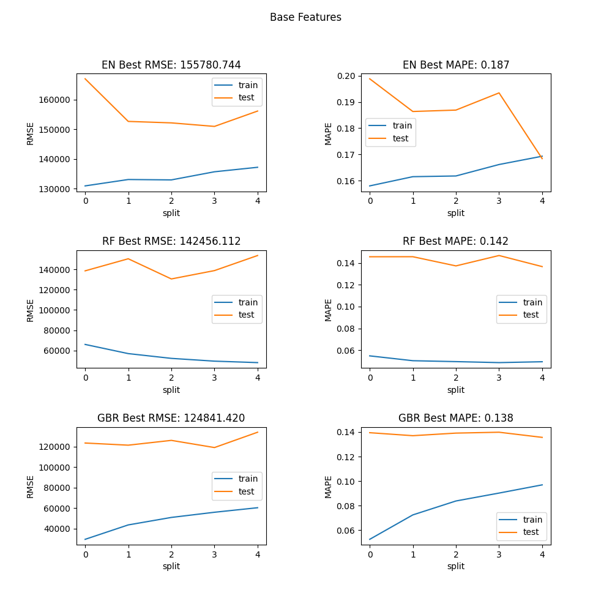

```python
EN_res = pd.DataFrame(grid_EN.cv_results_).loc[grid_EN.best_index_]
RF_res = pd.DataFrame(grid_RF.cv_results_).loc[grid_RF.best_index_]
GBR_res = pd.DataFrame(grid_GBR.cv_results_).loc[grid_GBR.best_index_]
results = [('EN', EN_res), ('RF', RF_res), ('GBR', GBR_res)]

graph_results('Base Features', results)
```

```python
print(grid_EN.best_params_, grid_RF.best_params_, grid_GBR.best_params_, sep='\n')
```

```
{'model__alpha': 0.1, 'model__l1_ratio': 1}
{'model__max_depth': 32, 'model__min_samples_leaf': 1, 'model__n_estimators': 1000}
{'model__learning_rate': 0.1, 'model__max_depth': 3, 'model__n_estimators': 1024}
```

### Experiment 2 - Reduced Features

```python
categorical_features = ['bedrooms','bathrooms','floors','waterfront','view','condition','grade',\
                        'yr_built','yr_renovated','zipcode','year','month']

numeric_features = ['sqft_living','sqft_basement','lat','sqft_living15']

X = data[numeric_features + categorical_features]
y = data['price']

preprocessor = build_preprocessor(numeric_features, categorical_features)
```

```python
%%time
grid_EN2 = GridSearchCV(Pipeline(steps=[('preprocessor', preprocessor), ('model', ElasticNet())]),
             param_grid=params['Elastic-Net'],
             cv=tss,
             scoring=scoring,
             refit='RMSE',
             return_train_score=True,
             n_jobs=4)

grid_EN2.fit(X, y)
```

```
CPU times: total: 5.48 s
Wall time: 48 s
```

```
GridSearchCV(cv=TimeSeriesSplit(gap=0, max_train_size=None, n_splits=5, test_size=None),
             estimator=Pipeline(steps=[('preprocessor',
                                        ColumnTransformer(transformers=[('numeric',
                                                                         StandardScaler(),
                                                                         ['sqft_living',
                                                                          'sqft_basement',
                                                                          'lat',
                                                                          'sqft_living15']),
                                                                        ('categorical',
                                                                         OneHotEncoder(handle_unknown='ignore'),
                                                                         ['bedrooms',
                                                                          'bathrooms',
                                                                          'floors',
                                                                          'waterfront',
                                                                          'view',
                                                                          'condition',
                                                                          'grade',
                                                                          'yr_built',
                                                                          'yr_renovated',
                                                                          'zipcode',
                                                                          'year',
                                                                          'month'])])),
                                       ('model', ElasticNet())]),
             n_jobs=4,
             param_grid={'model__alpha': [0, 0.1, 0.25, 0.5, 0.75, 1.0],
                         'model__l1_ratio': [0, 0.5, 1]},
             refit='RMSE', return_train_score=True,
             scoring={'MAPE': 'neg_mean_absolute_percentage_error',
                      'RMSE': 'neg_root_mean_squared_error'})
```

```python
%%time
grid_RF2 = GridSearchCV(Pipeline(steps=[('preprocessor', preprocessor), ('model', RandomForestRegressor())]),
             param_grid=params['Random Forest'],
             cv=tss,
             scoring=scoring,
             refit='RMSE',
             return_train_score=True,
             n_jobs=4)

grid_RF2.fit(X, y)
```

```
CPU times: total: 10min 10s
Wall time: 1h 36min 29s
```

```
GridSearchCV(cv=TimeSeriesSplit(gap=0, max_train_size=None, n_splits=5, test_size=None),
             estimator=Pipeline(steps=[('preprocessor',
                                        ColumnTransformer(transformers=[('numeric',
                                                                         StandardScaler(),
                                                                         ['sqft_living',
                                                                          'sqft_basement',
                                                                          'lat',
                                                                          'sqft_living15']),
                                                                        ('categorical',
                                                                         OneHotEncoder(handle_unknown='ignore'),
                                                                         ['bedrooms',
                                                                          'bathrooms',
                                                                          'floors',
                                                                          'waterfront',
                                                                          'view',
                                                                          '...
                                                                          'yr_built',
                                                                          'yr_renovated',
                                                                          'zipcode',
                                                                          'year',
                                                                          'month'])])),
                                       ('model', RandomForestRegressor())]),
             n_jobs=4,
             param_grid={'model__max_depth': [2, 4, 8, 16, 32],
                         'model__min_samples_leaf': [1, 3, 5, 10, 25],
                         'model__n_estimators': [100, 500, 1000, 1500]},
             refit='RMSE', return_train_score=True,
             scoring={'MAPE': 'neg_mean_absolute_percentage_error',
                      'RMSE': 'neg_root_mean_squared_error'})
```

```python
%%time
grid_GBR2 = GridSearchCV(Pipeline(steps=[('preprocessor', preprocessor), ('model', GradientBoostingRegressor())]),
             param_grid=params['Gradient Boosting Regressor'],
             cv=tss,
             scoring=scoring,
             refit='RMSE',
             return_train_score=True,
             n_jobs=4)

grid_GBR2.fit(X, y)
```

```
CPU times: total: 12.5 s
Wall time: 42min 3s
```

```
GridSearchCV(cv=TimeSeriesSplit(gap=0, max_train_size=None, n_splits=5, test_size=None),
             estimator=Pipeline(steps=[('preprocessor',
                                        ColumnTransformer(transformers=[('numeric',
                                                                         StandardScaler(),
                                                                         ['sqft_living',
                                                                          'sqft_basement',
                                                                          'lat',
                                                                          'sqft_living15']),
                                                                        ('categorical',
                                                                         OneHotEncoder(handle_unknown='ignore'),
                                                                         ['bedrooms',
                                                                          'bathrooms',
                                                                          'floors',
                                                                          'waterfront',
                                                                          'view',
                                                                          '...
                                                                          'yr_built',
                                                                          'yr_renovated',
                                                                          'zipcode',
                                                                          'year',
                                                                          'month'])])),
                                       ('model', GradientBoostingRegressor())]),
             n_jobs=4,
             param_grid={'model__learning_rate': [0.001, 0.01, 0.1],
                         'model__max_depth': [3, None],
                         'model__n_estimators': [128, 256, 512, 1024]},
             refit='RMSE', return_train_score=True,
             scoring={'MAPE': 'neg_mean_absolute_percentage_error',
                      'RMSE': 'neg_root_mean_squared_error'})
```

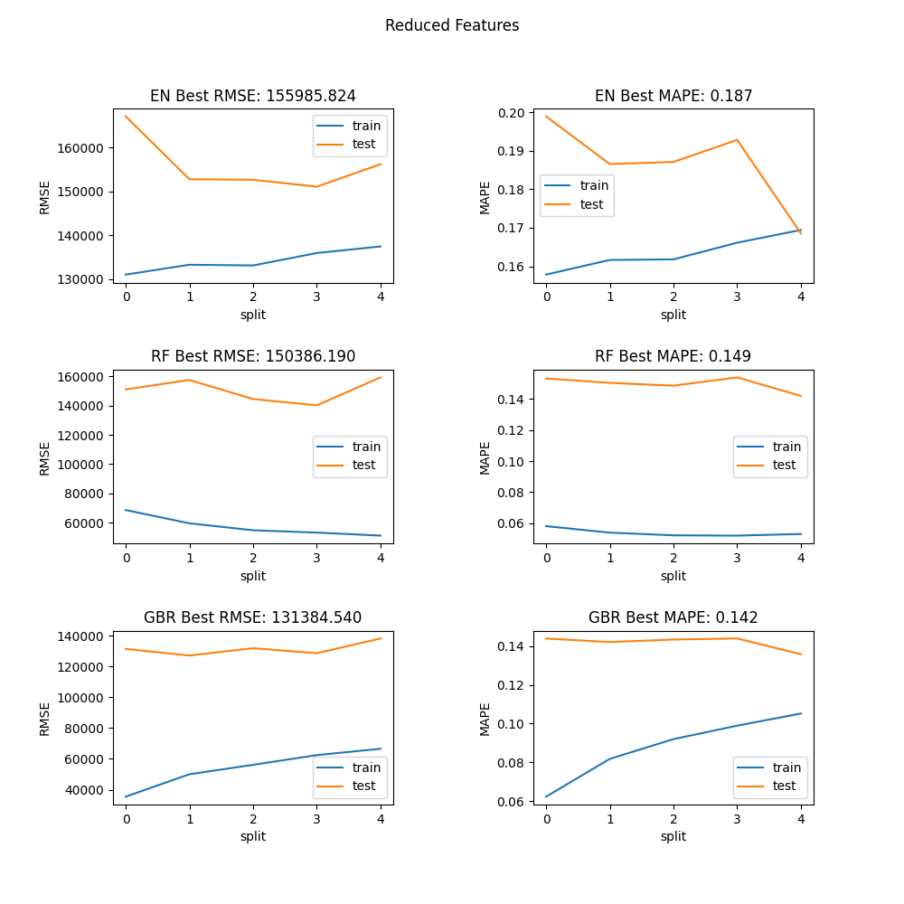

```python
EN_res2 = pd.DataFrame(grid_EN2.cv_results_).loc[grid_EN2.best_index_]
RF_res2 = pd.DataFrame(grid_RF2.cv_results_).loc[grid_RF2.best_index_]
GBR_res2 = pd.DataFrame(grid_GBR2.cv_results_).loc[grid_GBR2.best_index_]
results2 = [('EN', EN_res2), ('RF', RF_res2), ('GBR', GBR_res2)]

graph_results('Reduced Features', results2)
```

```python
print(grid_EN2.best_params_, grid_RF2.best_params_, grid_GBR2.best_params_, sep='\n')
```

```
{'model__alpha': 0.1, 'model__l1_ratio': 1}
{'model__max_depth': 32, 'model__min_samples_leaf': 1, 'model__n_estimators': 1000}
{'model__learning_rate': 0.1, 'model__max_depth': 3, 'model__n_estimators': 1024}
```

### Experiment 3 - Added Features

Include the engineered features `season` & `distance`

```python
categorical_features = ['bedrooms','bathrooms','floors','waterfront','view','condition','grade',\
                        'yr_built','yr_renovated','zipcode','year','season']

numeric_features = ['sqft_living','sqft_lot','sqft_above','sqft_basement','lat','long',\
                    'sqft_living15','sqft_lot15','zip_population','zip_schools','distance']

X = data[numeric_features + categorical_features]
y = data['price']

preprocessor = build_preprocessor(numeric_features, categorical_features)
```

```python
%%time
grid_EN3 = GridSearchCV(Pipeline(steps=[('preprocessor', preprocessor), ('model', ElasticNet())]),
             param_grid=params['Elastic-Net'],
             cv=tss,
             scoring=scoring,
             refit='RMSE',
             return_train_score=True,
             n_jobs=4)

grid_EN3.fit(X, y)
```

```
CPU times: total: 5.86 s
Wall time: 51.2 s
```

```
GridSearchCV(cv=TimeSeriesSplit(gap=0, max_train_size=None, n_splits=5, test_size=None),
             estimator=Pipeline(steps=[('preprocessor',
                                        ColumnTransformer(transformers=[('numeric',
                                                                         StandardScaler(),
                                                                         ['sqft_living',
                                                                          'sqft_lot',
                                                                          'sqft_above',
                                                                          'sqft_basement',
                                                                          'lat',
                                                                          'long',
                                                                          'sqft_living15',
                                                                          'sqft_lot15',
                                                                          'zip_population',
                                                                          'zip_schools',
                                                                          'distance']),
                                                                        ('categorical',
                                                                         OneHotE...
                                                                          'floors',
                                                                          'waterfront',
                                                                          'view',
                                                                          'condition',
                                                                          'grade',
                                                                          'yr_built',
                                                                          'yr_renovated',
                                                                          'zipcode',
                                                                          'year',
                                                                          'season'])])),
                                       ('model', ElasticNet())]),
             n_jobs=4,
             param_grid={'model__alpha': [0, 0.1, 0.25, 0.5, 0.75, 1.0],
                         'model__l1_ratio': [0, 0.5, 1]},
             refit='RMSE', return_train_score=True,
             scoring={'MAPE': 'neg_mean_absolute_percentage_error',
                      'RMSE': 'neg_root_mean_squared_error'})
```

```python
%%time
grid_RF3 = GridSearchCV(Pipeline(steps=[('preprocessor', preprocessor), ('model', RandomForestRegressor())]),
             param_grid=params['Random Forest'],
             cv=tss,
             scoring=scoring,
             refit='RMSE',
             return_train_score=True,
             n_jobs=4)

grid_RF3.fit(X, y)
```

```
CPU times: total: 12min 57s
Wall time: 2h 11min 56s
```

```
GridSearchCV(cv=TimeSeriesSplit(gap=0, max_train_size=None, n_splits=5, test_size=None),
             estimator=Pipeline(steps=[('preprocessor',
                                        ColumnTransformer(transformers=[('numeric',
                                                                         StandardScaler(),
                                                                         ['sqft_living',
                                                                          'sqft_lot',
                                                                          'sqft_above',
                                                                          'sqft_basement',
                                                                          'lat',
                                                                          'long',
                                                                          'sqft_living15',
                                                                          'sqft_lot15',
                                                                          'zip_population',
                                                                          'zip_schools',
                                                                          'distance']),
                                                                        ('categorical',
                                                                         OneHotE...
                                                                          'yr_built',
                                                                          'yr_renovated',
                                                                          'zipcode',
                                                                          'year',
                                                                          'season'])])),
                                       ('model', RandomForestRegressor())]),
             n_jobs=4,
             param_grid={'model__max_depth': [2, 4, 8, 16, 32],
                         'model__min_samples_leaf': [1, 3, 5, 10, 25],
                         'model__n_estimators': [100, 500, 1000, 1500]},
             refit='RMSE', return_train_score=True,
             scoring={'MAPE': 'neg_mean_absolute_percentage_error',
                      'RMSE': 'neg_root_mean_squared_error'})
```

```python
%%time
grid_GBR3 = GridSearchCV(Pipeline(steps=[('preprocessor', preprocessor), ('model', GradientBoostingRegressor())]),
             param_grid=params['Gradient Boosting Regressor'],
             cv=tss,
             scoring=scoring,
             refit='RMSE',
             return_train_score=True,
             n_jobs=4)

grid_GBR3.fit(X, y)
```

```
CPU times: total: 25.5 s
Wall time: 57min 16s
```

```
GridSearchCV(cv=TimeSeriesSplit(gap=0, max_train_size=None, n_splits=5, test_size=None),
             estimator=Pipeline(steps=[('preprocessor',
                                        ColumnTransformer(transformers=[('numeric',
                                                                         StandardScaler(),
                                                                         ['sqft_living',
                                                                          'sqft_lot',
                                                                          'sqft_above',
                                                                          'sqft_basement',
                                                                          'lat',
                                                                          'long',
                                                                          'sqft_living15',
                                                                          'sqft_lot15',
                                                                          'zip_population',
                                                                          'zip_schools',
                                                                          'distance']),
                                                                        ('categorical',
                                                                         OneHotE...
                                                                          'yr_built',
                                                                          'yr_renovated',
                                                                          'zipcode',
                                                                          'year',
                                                                          'season'])])),
                                       ('model', GradientBoostingRegressor())]),
             n_jobs=4,
             param_grid={'model__learning_rate': [0.001, 0.01, 0.1],
                         'model__max_depth': [3, None],
                         'model__n_estimators': [128, 256, 512, 1024]},
             refit='RMSE', return_train_score=True,
             scoring={'MAPE': 'neg_mean_absolute_percentage_error',
                      'RMSE': 'neg_root_mean_squared_error'})
```

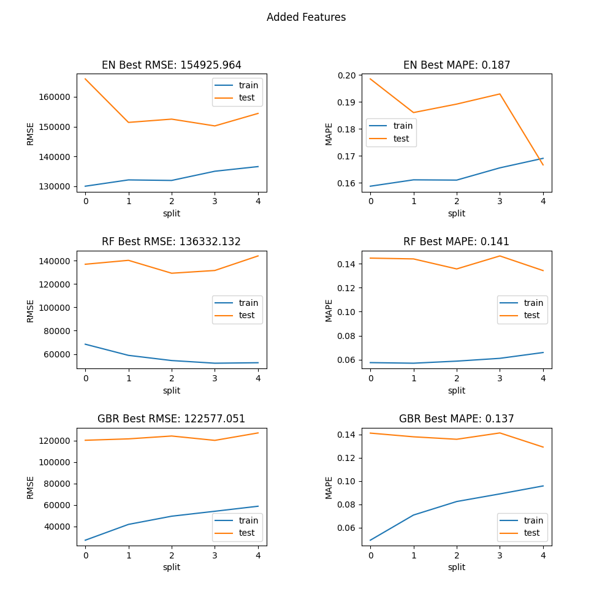

```python
EN_res3 = pd.DataFrame(grid_EN3.cv_results_).loc[grid_EN3.best_index_]
RF_res3 = pd.DataFrame(grid_RF3.cv_results_).loc[grid_RF3.best_index_]
GBR_res3 = pd.DataFrame(grid_GBR3.cv_results_).loc[grid_GBR3.best_index_]
results3 = [('EN', EN_res3), ('RF', RF_res3), ('GBR', GBR_res3)]

graph_results('Added Features', results3)
```

```python
print(grid_EN3.best_params_, grid_RF3.best_params_, grid_GBR3.best_params_, sep='\n')
```

```
{'model__alpha': 1.0, 'model__l1_ratio': 1}
{'model__max_depth': 16, 'model__min_samples_leaf': 1, 'model__n_estimators': 1500}
{'model__learning_rate': 0.1, 'model__max_depth': 3, 'model__n_estimators': 1024}
```

### Results

Based on the experiments, we would likely choose Gradient Boosted Regression Model with the added engineered features and the following parameters: {'learning_rate': 0.1, 'max_depth': 3, 'n_estimators': 1024}

Although it doesn't have a fitting time as fast as something like Elastic-Net, it should be fast enough for our purposes. Its prediction time is also decently fast when using just a CPU.

## Pipeline Upload

Leftover from before the Project 3 change - can be ignored

```python
import pickle
```

```python
categorical_features = ['bedrooms','bathrooms','floors','waterfront','view','condition','grade','yr_built','yr_renovated','zipcode']
numeric_features = ['sqft_living','sqft_lot','sqft_above','sqft_basement','lat','long','sqft_living15','sqft_lot15','zip_population','zip_schools']

preprocessor = ColumnTransformer(
    transformers=[
        ('numeric', StandardScaler(), numeric_features),
        ('categorical', OneHotEncoder(handle_unknown='ignore'), categorical_features)
    ])

model = GradientBoostingRegressor() # TODO

pipeline = Pipeline(steps=[('preprocessor', preprocessor),
                           ('model', model)])
```

```python
with open('pipeline.pkl', 'wb') as f:
    pickle.dump(pipeline, f)
```

```python
resp = minio_client.fput_object('modeling', 'model-training-configurations/pipeline.pkl', 'pipeline.pkl')
```